# R Notebook

累積的な変異によって生じる設計の浮動(20160303_JSSD_Inheritance_11J_resubmission4.pdf)のやりなおし。t-SNEもしくはUMAPで画像をとってみて、うまくいけばその距離がどう変遷したかを追う。きれいにすすすっと動いていくものと、がくっがくっと変わるものがあり、がくがく変わるのは断続平衡説のように？ 指示によるものだから、それによってなんか傾きとかが言えるといいんだけどねえ あんまりresubmissionを目指さず、umapの練習だと思いたい。ああいやだ

# 練習

[Uniform Manifold Approximation and Projection in R](https://cran.r-project.org/web/packages/umap/vignettes/umap.html)をもとにまずは練習。

```r
install.packages("irlba") # for Rtsne partial PCA
```

```r
library(umap)
library(tidyverse)
library(snedata)
library(imager)
library(purrr)
library(Rtsne)
library(irlba)
```

## iris

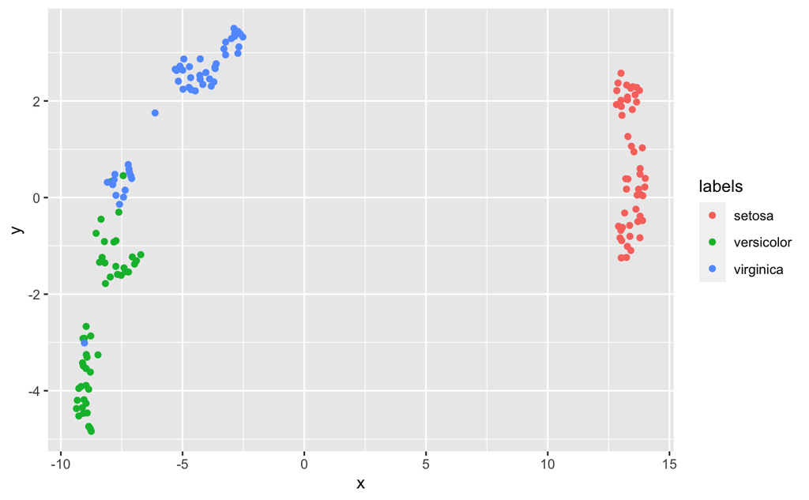

## MNIST

https://jlmelville.github.io/uwot/umap-examples.html

```r
mnist_umap <- mnist_df |>
  umap(
  pca = 10,
  verbose = TRUE,
  n_threads = 5
  )
```

```
[2022-08-18 11:27:13]  starting umap
[2022-08-18 11:27:13]  creating graph of nearest neighbors
```

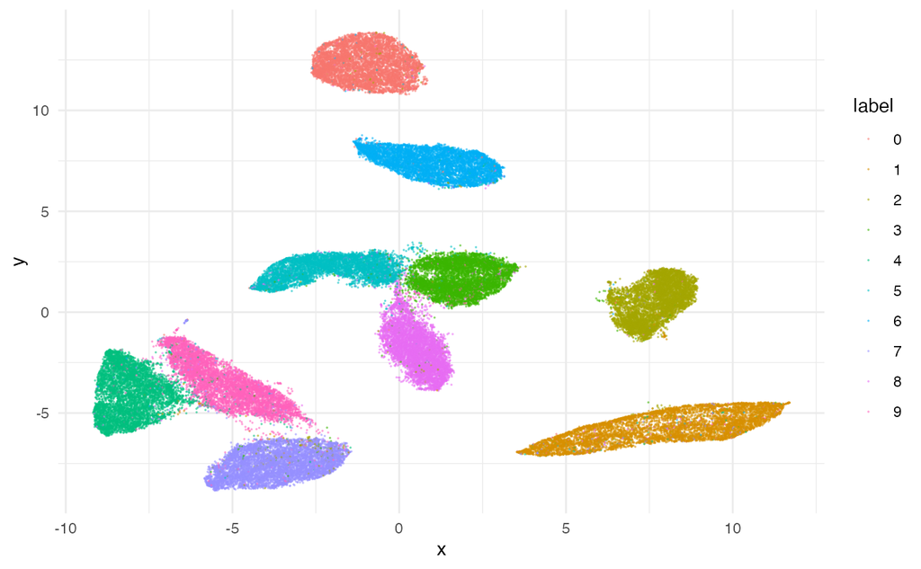

# convert image jpg files into dataframe

{imager} https://dahtah.github.io/imager/imager.html

```r
getwd()
# file <- system.file('/Users/mm/Documents/transmission-chain-tsne/2-1_000.jpg', package = "imager") # doesn't work
load.image("./2-1_000.jpg") |> plot()
load.image("./2-1_000.jpg") |>  deriche(2,order=2,axis="x") |> plot()#Edge detector along x-axis
a <- boats > 250
test_img <- load.image()
test_img
test_img |>
  resize(size_x = 128, size_y = 128) |> # https://rdrr.io/cran/imager/man/resize.html
  grayscale() |> # somehow 3 channels
  as.numeric()
826*826
```

```r
df_one <-
  paste0(
    "input/drawing/2-1_",
    formatC(0:41, width = 3, flag = "0"),
    ".jpg"
  ) |>
  map(~ load.image(file = .x)) |>
  map(~ resize(im = .x, size_x = 128, size_y = 128)) |>
  map(~ grayscale(im = .x)) |>
  map(~t(as.numeric(.))) |>
  map_dfr(~ as.data.frame(.))

df_two <-
  paste0(
    "input/drawing/2-2_",
    formatC(0:41, width = 3, flag = "0"),
    ".jpg"
  ) |>
  map(~ load.image(file = .x)) |>
  map(~ resize(im = .x, size_x = 128, size_y = 128)) |>
  map(~ grayscale(im = .x)) |>
  map(~t(as.numeric(.))) |>
  map_dfr(~ as.data.frame(.))
df_three <-
  paste0(
    "input/drawing/2-3_",
    formatC(0:41, width = 3, flag = "0"),
    ".jpg"
  ) |>
  map(~ load.image(file = .x)) |>
  map(~ resize(im = .x, size_x = 128, size_y = 128)) |>
  map(~ grayscale(im = .x)) |>
  map(~t(as.numeric(.))) |>
  map_dfr(~ as.data.frame(.))
df_four <-
  paste0(
    "input/drawing/2-4_",
    formatC(0:41, width = 3, flag = "0"),
    ".jpg"
  ) |>
  map(~ load.image(file = .x)) |>
  map(~ resize(im = .x, size_x = 128, size_y = 128)) |>
  map(~ grayscale(im = .x)) |>
  map(~t(as.numeric(.))) |>
  map_dfr(~ as.data.frame(.))
df_five <-
  paste0(
    "input/drawing/2-5_",
    formatC(0:38, width = 3, flag = "0"),
    ".jpg"
  ) |>
  map(~ load.image(file = .x)) |>
  map(~ resize(im = .x, size_x = 128, size_y = 128)) |>
  map(~ grayscale(im = .x)) |>
  map(~t(as.numeric(.))) |>
  map_dfr(~ as.data.frame(.))
df_six <-
  paste0(
    "input/drawing/2-6_",
    formatC(0:41, width = 3, flag = "0"),
    ".jpg"
  ) |>
  map(~ load.image(file = .x)) |>
  map(~ resize(im = .x, size_x = 128, size_y = 128)) |>
  map(~ grayscale(im = .x)) |>
  map(~t(as.numeric(.))) |>
  map_dfr(~ as.data.frame(.))
df_seven <-
  paste0(
    "input/drawing/2-7_",
    formatC(0:38, width = 3, flag = "0"),
    ".jpg"
  ) |>
  map(~ load.image(file = .x)) |>
  map(~ resize(im = .x, size_x = 128, size_y = 128)) |>
  map(~ grayscale(im = .x)) |>
  map(~t(as.numeric(.))) |>
  map_dfr(~ as.data.frame(.))
df_eight <-
  paste0(
    "input/drawing/2-8_",
    formatC(0:41, width = 3, flag = "0"),
    ".jpg"
  ) |>
  map(~ load.image(file = .x)) |>
  map(~ resize(im = .x, size_x = 128, size_y = 128)) |>
  map(~ grayscale(im = .x)) |>
  map(~t(as.numeric(.))) |>
  map_dfr(~ as.data.frame(.))
```

```r
df_all <-
  list.files("input/drawing/", full.names=T) |>
  map(~ load.image(file = .x)) |>
  map(~ resize(im = .x, size_x = 128, size_y = 128))
df_all <- df_all |>
  map(~ grayscale(im = .x)) |>
  map(~t(as.numeric(.))) |>
  map_dfr(~ as.data.frame(.))
```

```r
# exp 2-5, 2-7: T=38
one_umap <- df_one |>
  umap()
two_umap <- df_two |>
  umap()
three_umap <- df_three |>
  umap()
four_umap <- df_four |>
  umap()
five_umap <- df_five |>
  umap()
six_umap <- df_six |>
  umap()
seven_umap <- df_seven |>
  umap()
eight_umap <- df_eight |>
  umap()
all_umap <- df_all |>
  umap()


one_umap_df <- one_umap$layout |>
  as_tibble() |>
  transmute(x = V1, y = V2) |>
  mutate(exp = rep(1, 42), t = 0:41)
one_umap_df |> View()
two_umap_df <- two_umap$layout |>
  as_tibble() |>
  transmute(x = V1, y = V2) |>
  mutate(exp = rep(2, 42), t = 0:41)
three_umap_df <- three_umap$layout |>
  as_tibble() |>
  transmute(x = V1, y = V2) |>
  mutate(exp = rep(3, 42), t = 0:41)
four_umap_df <- four_umap$layout |>
  as_tibble() |>
  transmute(x = V1, y = V2) |>
  mutate(exp = rep(4, 42), t = 0:41)
five_umap_df <- five_umap$layout |>
  as_tibble() |>
  transmute(x = V1, y = V2) |>
  mutate(exp = rep(5, 39), t = 0:38)
six_umap_df <- six_umap$layout |>
  as_tibble() |>
  transmute(x = V1, y = V2) |>
  mutate(exp = rep(6, 42), t = 0:41)
seven_umap_df <- seven_umap$layout |>
  as_tibble() |>
  transmute(x = V1, y = V2) |>
  mutate(exp = rep(7, 39), t = 0:38)
eight_umap_df <- eight_umap$layout |>
  as_tibble() |>
  transmute(x = V1, y = V2) |>
  mutate(exp = rep(8, 42), t = 0:41)
all_umap_df <- all_umap$layout |>
  as_tibble() |>
  transmute(x = V1, y = V2)
```

```r
experiments_df <- bind_rows(one_umap_df, two_umap_df, three_umap_df, four_umap_df, five_umap_df, six_umap_df, seven_umap_df, eight_umap_df)

experiments_df |>
  ggplot(aes(x = x, y = y, colour = t)) +
  geom_point(size = .3) +
  # geom_path() +
  geom_text(aes(label = t), hjust = 0, nudge_x = .1, size = 2) +
  scale_colour_viridis_c() +
  theme_minimal() +
  facet_wrap(facets = vars(exp), nrow = 2) +
  theme(
    panel.grid = element_blank(),
    axis.line = element_line())
```

### test: plot UMAP for all drawings, from Exp1-8

```r
all_umap_df2 <- all_umap_df |>
  mutate(filename = list.files("input/drawing/")) |>
  mutate(experiment = str_match(filename, "2-(\\d)")[,2] |> as.numeric(),
         t = str_extract(filename, "\\d{3}") |> as.numeric())
```

```r
all_umap_df2 |>
  ggplot(aes(x = x, y = y, colour = experiment |> as.factor())) +
  geom_point(size = .3) +
  # geom_path(aes(colour = t, group = experiment)) +
  geom_text(aes(label = t), hjust = 0, nudge_x = .1, size = 2) +
  # scale_colour_viridis_d() +
  theme_minimal() +
  theme(
    panel.grid = element_blank(),
    axis.line = element_line())
```

## tune

そもそもデフォルトの値で、しかもUMAPなのがまずいような気もする。Large datasetが基本だと思うので。UMAP以外とか、PCAとか、色々見直してみよう。

### t-SNE

[R wrapper for Van der Maaten’s Barnes-Hut implementation of t-Distributed Stochastic Neighbor Embedding](https://github.com/jkrijthe/Rtsne)

t-SNEのクラスターサイズは何も意味しない、距離もあんまり意味ないかも：https://distill.pub/2016/misread-tsne/

というか、伝達連鎖法の順番をこういう方法で復元できる、という論文にするか？こんなにいろいろな条件でもロバストに順番がだいたいわかりますよ、みたいな。距離は関係ないのだとしたら。

練習

```r
iris_unique <- unique(iris) # Remove duplicates
set.seed(42) # Sets seed for reproducibility
tsne_out <- Rtsne(as.matrix(iris_unique[,1:4])) # Run TSNE
plot(tsne_out$Y,col=iris_unique$Species,asp=1) # Plot the result
```

Perplexityはデータサイズの1/3が上限[らしい](https://www.slideshare.net/kato_kohaku/dimensionality-reduction-with-tsne-and-umap-using-r-176806642)(p21)。

```r
# Rtsne(df_seven) # error, perplexity (default 30) too large
seven_tsne <- df_seven |> select(-t) |>
  as.matrix() |>
  Rtsne(
    perplexity = 12, # default 30, max datasize/3
    exaggeration_factor = 15,  # default 12
    n_threads = 4,
    verbose = TRUE,
    max_iter = 3000
  )
seven_tsne_df <- seven_tsne$Y |>
  as_tibble() |>
  rename(x = "V1", y = "V2") |>
  mutate(t = 0:38)
seven_tsne_df |>
  ggplot(aes(x = x, y = y, colour = t)) +
  geom_point(size = .3) +
  geom_path() +
  geom_text(aes(label = t), hjust = 0, nudge_x = .1, size = 2) +
  scale_colour_viridis_c() +
  theme_minimal() +
  theme(
    panel.grid = element_blank(),
    axis.line = element_line())
```

だめですね！！

### UMAP改善

デフォルトの値は`umap.defaults`

```r
umap.defaults
```

```r
seven_umap2 <- df_seven |>
  mutate(across(everything(), as.numeric)) |> # なぜか必要。なぜ
  umap(verbose = TRUE,
       n_threads = 6,
       pca = 100, # 何も変わらん
       min_dist =  .01, # default = .1
       spread = .5
       )

seven_umap2_df <- seven_umap2$layout |>
  as_tibble() |>
  transmute(x = V1, y = V2) |>
  mutate(exp = rep(7, 39), t = 0:38)

seven_umap2_df |>
  ggplot(aes(x = x, y = y, colour = t)) +
  geom_point(size = .3) +
  geom_path() +
  geom_text(aes(label = t), hjust = 0, nudge_x = .1, size = 2) +
  scale_colour_viridis_c() +
  theme_minimal() +
  # facet_wrap(facets = vars(exp), nrow = 2) +
  theme(
    panel.grid = element_blank(),
    axis.line = element_line())
ggsave("./output/exp2-7_mindist01spread3.png")
```

比較をいろいろしてみよう [purrr inside mutate](https://dcl-prog.stanford.edu/purrr-mutate.html)

```r
df_seven2 <- df_seven |>
  mutate(across(everything(), as.numeric))
nested_df_grid_conditions <-
  expand_grid(min_dist = c(2^(-4:-1)), n_neighbors = 2^(1:4)) |>
  mutate(
    umap = map2(
      min_dist,
      n_neighbors,
      ~ umap(
        df_seven2,
        spread = 2,
        n_threads = 4,
        min_dist = .x,
        n_neighbors = .y
      )
    )
  )
# unnest
# unnesting a column of matrices doesn't unnest well
# cf. https://community.rstudio.com/t/understanding-unnest-and-its-expectations/428 alistaire
# but this method does not work either.
# instead we use deframe but it cannot be performed in one long pipe
df_unnested_matrix_column <-
  nested_df_grid_conditions |>
  rowwise() |>
  mutate(umap_df = umap |> extract2(1) |> list()) |>
  mutate(umap = NULL) |>
  ungroup() |>
  unnest_longer(umap_df, indices_to = "t")


df_matrix_only <-
  df_unnested_matrix_column |>
  select(umap_df) |>
  deframe() |>
  as_tibble()
df_grid_conditions <-
  bind_cols(
    df_unnested_matrix_column,
    df_matrix_only
  ) |>
  select(-umap_df) |>
  rename(x = "V1", y = "V2")
```

## plot

```r
df_grid_conditions |> colnames()
df_grid_conditions |>
  ggplot(aes(x = x, y = y, colour = t)) +
  geom_point(size = .3) +
  geom_path(size = .1) +
  scale_colour_viridis_c() +
  facet_grid(rows = vars(min_dist), cols = vars(n_neighbors)) +
  theme_minimal() +
  theme(
    panel.grid = element_blank(),
    axis.line = element_line())
```